# FML Assignment4

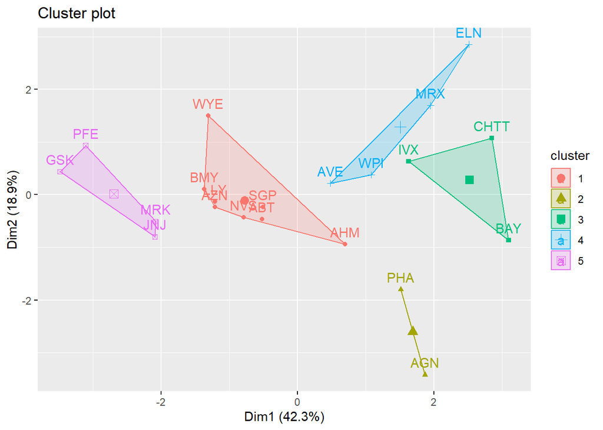

```r
fviz_cluster(clusterx, data = Pharma2)
```

Manhattan Distance when using Kmeans Clustering.

```r
set.seed(21)
# Use kcca function to create 5 clusters with Manhattan distance and k-medians algorithm
clusterY <- kcca(Pharma2, k = 5, kccaFamily("kmedians"))
# Print the results and visualize the clusters
clusterY
```

```
## kcca object of family 'kmedians'
##
## call:
## kcca(x = Pharma2, k = 5, family = kccaFamily("kmedians"))
##
## cluster sizes:
##
##  1  2  3  4  5
##  4 10  2  4  1
```

```r
clusters_index <- predict(clusterY)
dist(clusterY@centers)
```

```
##          1        2        3        4
## 2 2.663586
## 3 2.113529 3.531320
## 4 2.359668 4.474483 3.022624
## 5 2.582322 3.396689 2.360814 3.868401
```

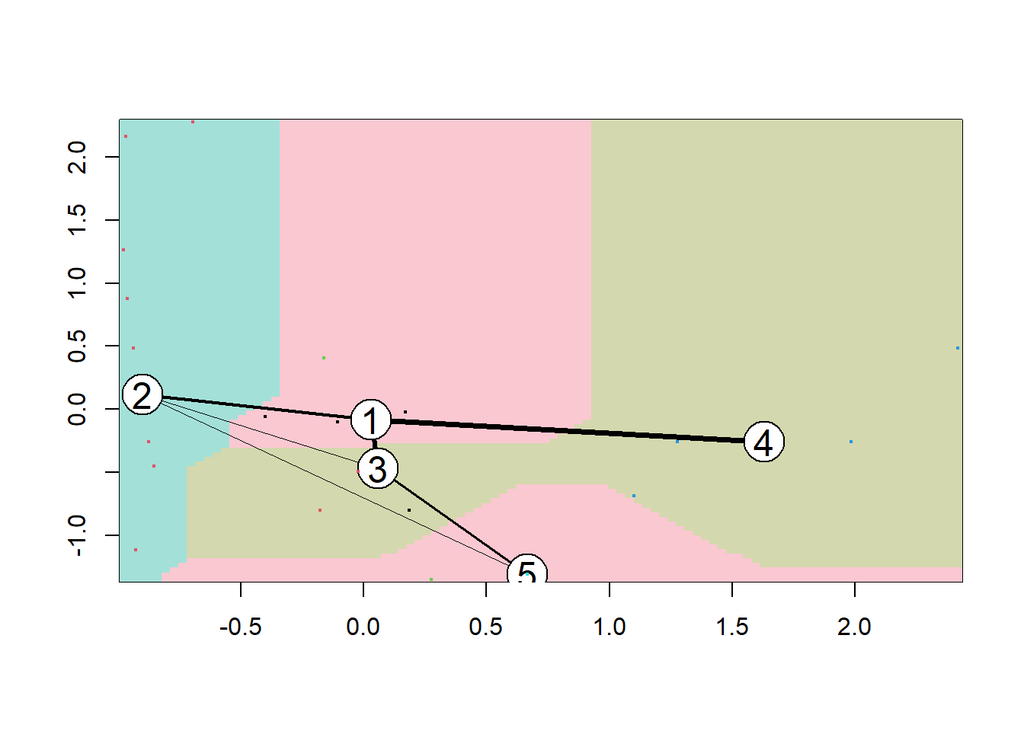

```r
image(clusterY)
points(Pharma2, col = clusters_index, pch = 19, cex = 0.3)
```

```r
library(tidyverse)
Pharma1 %>% mutate(Cluster = clusterx$cluster) %>% group_by(Cluster) %>% summarise_all("mean")
```

```
## # A tibble: 5 × 10
##   Cluster Market_Cap  Beta PE_Ratio   ROE   ROA Asset_Turnover Leverage
##     <int>      <dbl> <dbl>    <dbl> <dbl> <dbl>          <dbl>    <dbl>
## 1       1      55.8  0.414     20.3  28.7 12.7           0.738    0.371
## 2       2      31.9  0.405     69.5  13.2  5.6           0.75     0.475
## 3       3       6.64 0.87      24.6  16.5  4.17          0.6      1.65
## 4       4      13.1  0.598     17.7  14.6  6.2           0.425    0.635
## 5       5     157.   0.48      22.2  44.4 17.7           0.95     0.22
## # ℹ 2 more variables: Rev_Growth <dbl>, Net_Profit_Margin <dbl>
```

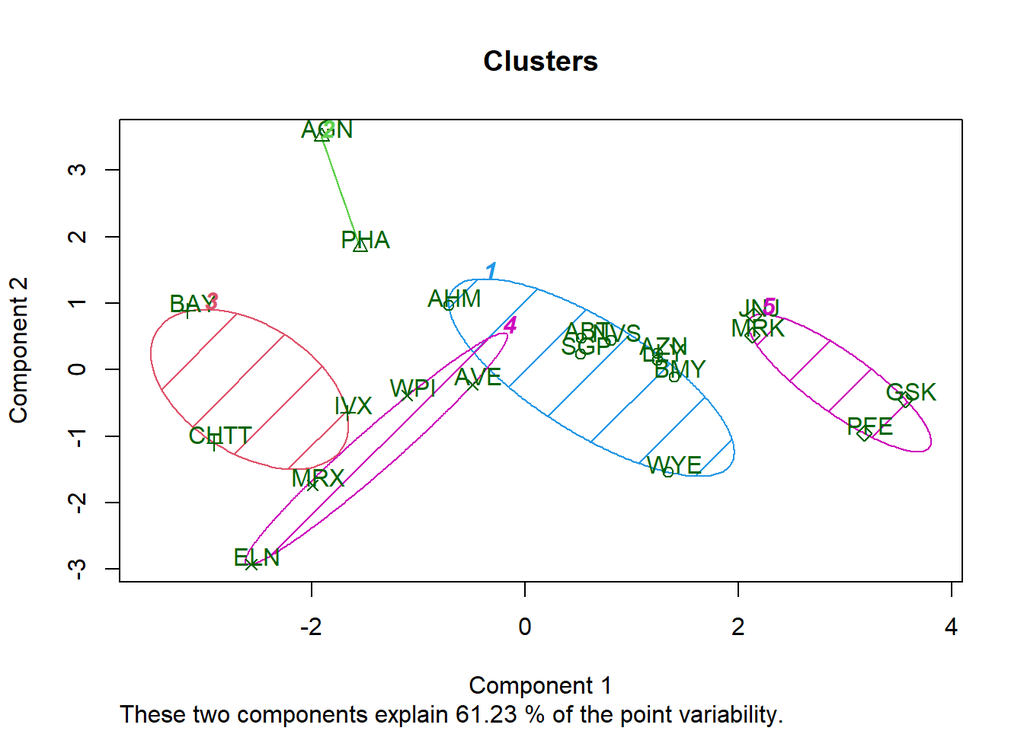

```r
clusplot(Pharma2,clusterx$cluster, main="Clusters",color = TRUE,shade = TRUE, labels = 2,lines = 0)
```

Companies are classified into different clusters as follows

Cluster1 : AHM,WYE,BMY,AZN,LLY,ABT,NVS,ABT and SGP

Cluster2 : AGN,PHA

Cluster3 : BAY,CHTT,IVX

Cluster4 : ELN,MRX,WPI,AVE

Cluster5 : JNJ,MRK,PFE,GSK

From the means of the cluster variables, it can be derived as follow:

Cluster1 has a medium risk

Cluster2 has very high PE Ratio

Cluster4 has the best Net Profit Margin, the lowest PE ratio, and the fastest sales growth. It can be bought or kept on hand as a reserve.

Cluster5 has strong market capitalization, ROI, ROA, ROA on assets, ROA on turnover of assets, and ROA on net profit margin. A low PE ratio indicates that the stock price is moderately valued and may thus be bought and kept. Revenue growth of 18.5% is also favorable.

Examining patterns by visualizing clusters against the variables

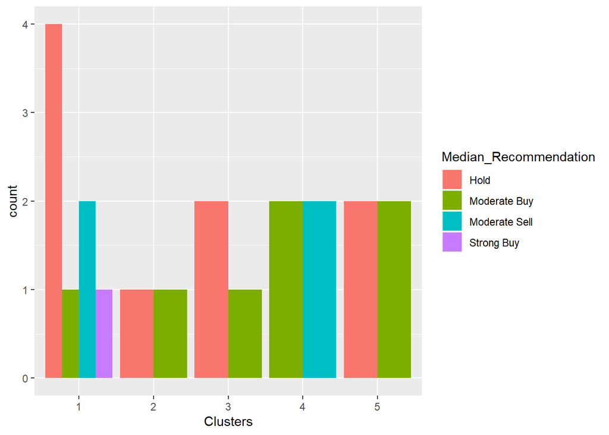

```r
Pharma3 <- Pharma[12:14] %>% mutate(Clusters=clusterx$cluster)
ggplot(Pharma3, mapping = aes(factor(Clusters), fill =Median_Recommendation)) +
 geom_bar(position='dodge') + labs(x ='Clusters')
```

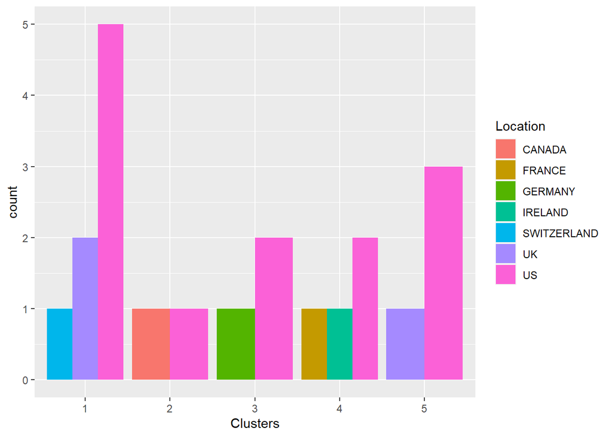

```r
ggplot(Pharma3, mapping = aes(factor(Clusters),fill = Location)) +
 geom_bar(position = 'dodge') + labs(x ='Clusters')
```

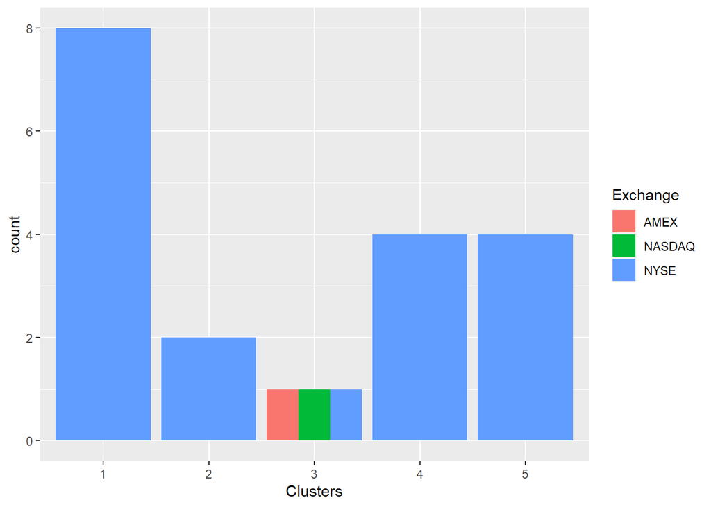

```r
ggplot(Pharma3, mapping = aes(factor(Clusters),fill = Exchange)) +
 geom_bar(position = 'dodge') + labs(x ='Clusters')
```

Provide an appropriate name for each cluster using any or all of the variables in the data set.

Cluster1: Attempt it Cluster

Cluster2: Significant Risk Cluster

Cluster3: Very Dangerous Cluster

Cluster4: Top Buying Cluster

Cluster5: A Perfect Asset